# Perfil Motivacional y Expectativas Profesionales - Resultados Extendidos

Fabrizio Andrés García Seleme

2024-09-24

El presente documento contiene una extensión de la presentación de los resultados del trabajo “Perfil motivacional y expectativas profesionales en estudiantes de primer año de medicina FCM UNC 2024” presentado en las XXV Jornadas de Investigación Científica de la Facultad de Ciencias Médicas de la Universidad Nacional de Córdoba (FCM-UNC).

Este trabajo fue realizado por las docentes Méd. Esp. M. Lucía Seleme, Méd. Laura D. Ascar y Dra. Viviana M. del V. Combina; de la Cátedra de Salud Comunitaria I FCM-UNC, con la colaboración del Ing. Agr. Fabrizio A. García Seleme, de la Cátedra de Estadística y Biometría de la Facultad de Ciencias Agropecuarias UNC, en carácter de asesor.

Este documento permanecerá público en el repositorio GitHub del Ing. Agr. Fabrizio García Seleme, al cual puede acceder haciendo click aquí.

## Introducción

La elección de una carrera universitaria es determinante; especialmente en medicina implica un gran compromiso personal. Este trabajo busca identificar las motivaciones que llevan a elegir la carrera de medicina y las expectativas de desarrollo profesional.

## Materiales y Métodos

Se realizó una investigación cuantitativa, con un diseño de tipo descriptivo de corte transversal. Se ofreció a estudiantes del primer cuatrimestre de primer año de la carrera de Medicina (FCM-UNC) completar una encuesta anónima en Google Forms sobre sus motivaciones para elegir la carrera de medicina, sus preocupaciones y el interés por especializaciones futuras. Conjuntamente se registró la edad y sexo de los estudiantes, como así también otros datos como su lugar de origen, nivel educativo de los padres, situación laboral, etc.

Los datos fueron procesados y analizados con InfoStat, en tanto que las salidas gráficas y el presente informe fueron realizados con las librerías `ggplot2`, `GGally` y `markdown` de R.

## Resultados

### Carga y visualización de datos

De las respuestas se lograron obtener 27 variables. A continuación se muestran aquellas vinculadas a los antecedentes de los estudiantes (no variables respuesta), junto a los valores de las primeras observaciones.

| SEXO | EDAD | FIN.SECU | ANO.UNIV | MUDANZA | LOCALIDAD_1 | TRABAJO | EDUC.PADRE | EDUC.MADRE |
| --- | --- | --- | --- | --- | --- | --- | --- | --- |
| Femenino | 20 | 2021.PREV | SI.VARIOS.INTENTOS | SI.OTROS | vamercedes | SI.NO.NECESITA | SC | SI |
| Femenino | 19 | 2022 | NO.CURSO.MEDIC.OTRA.UNI | NO | NA | NO.NO.NECESITA | TI | TC |
| Femenino | 24 | 2021.PREV | SI.VARIOS.INTENTOS | SI.OTROS | Tartagal | NO.SI.NECESITA | TI | TI |
| Otro | 22 | 2021.PREV | NO.CURSA.OTRA.CARRERA | NO | NA | NO.NO.NECESITA | TC | TC |
| Femenino | 19 | 2022 | SI.VARIOS.INTENTOS | SI.OTROS | laboulaye | NO.NO.NECESITA | SC | TC |
| Masculino | 20 | 2023 | SI.PRIMER.INGRESO | SI.OTROS | neuquen | NO.NO.NECESITA | SC | TI |

Descripción de los valores de cada variable:

- `SEXO`: presenta tres categorías: Masculino, Femenino y Otro.
- `Edad` : medida en años.
- `FIN.SECU` : año en el que el estudiante terminó sus estudios secundarios, siendo las opciones 2023, 2022 y anterior a 2021.
- `ANO.UNIV` : consulta sobre si este año es el primero en el que cursan una carrera universitaria. En caso afirmativo, se indaga sobre si rindieron el ingreso más de una vez. En caso negativo, se consulta sobre el antecedente de cursado, si fue en otra universidad o en otra carrera.
- `MUDANZA` : indaga si los estudiantes se mudaron para iniciar sus estudios.
- `LOCALIDAD_1` : transformación de la variable original de la encuesta que solicitaba aclarar la localidad de donde procede el estudiante. Se homogeinizó la denominación de ciertas localidades y se removió el nombre de la provincia, ocasionalmente presente. Casos en los que no se completó y que indicaron no haberse mudado se asumieron procedentes de Córdoba Capital, lo que fue aclarado en la misma encuesta.
- `TRABAJO` : situación laboral del estudiante, dividida entre la situación actual (trabaja/no trabaja) y la situación proyectada (necesita trabajar para seguir estudiando o no).
- `EDUC.PADRE` y `EDUC.MADRE` : nivel educativo de los padres, con categorías primario incompleto (PI) o completo (PC), secundario incompleto (SI) o completo (SC), terciario incompleto (TI) o completo (TC) y no sabe/no contesta.

Los valores que figuran en la tabla son simplificaciones de las opciones mostradas a los estudiantes en el formulario que tienen por objetivo facilitar el procesamiento informático de los datos.

### Análisis demográfico de los encuestados

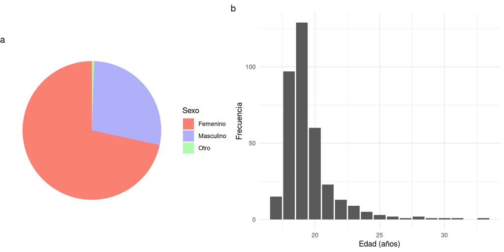

**Figura 1**. Gráfico de sectores de las frecuencias de cada sexo (a), y gráfico de las frecuencias de cada edad (b) en la muestra de estudiantes de medicina (n = 363).

Respecto al año de finalización de estudios secundarios, los estudiantes se repartieron homogéneamente entre las opciones “el año pasado” (28.7%), en 2022 (39.4%) y en 2021 o antes (31.9%). La baja proporción de estudiantes egresados del secundario en 2023 se relaciona con un bajo porcentaje de estudiantes que rindieron el ingreso una única vez (31.4%). Un porcentaje mayor de alumnos aseguró haberlo rendido en más de una ocasión (54.5%). Un 14% ya había estado alguna vez en una carrera universitaria, ya sea otra carrera (11.8%), o la carrera de medicina de otra institución(2.2%). Al observar en detalle los estudiantes que rindieron el ingreso más de una vez, es posible notar que dos terceras partes de ellos terminaron el secundario en 2022 (Figura 2), dando a entender que en 2023 habría sido su segundo intento. Por otro lado, el tercio restante corresponde a estudiantes que llevan más tiempo de egresados. Los grupos que ya habían cursado en la universidad anteriormente llevan más tiempo de egresados del secundario; además presentan una edad promedio significativamente superior (ANAVA, p < 0.05) respecto a los grupos que en 2024 cursaron por primera vez.

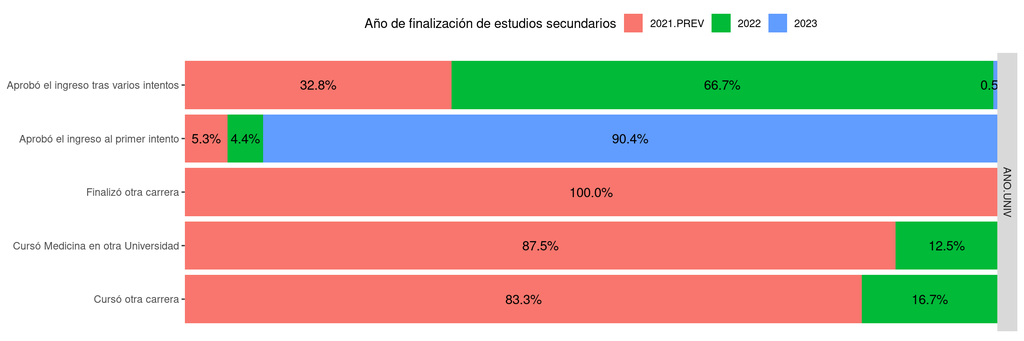

**Figura 2**. Proporción de año de egreso del secundario por cada situación respecto al ingreso a la universidad de estudiantes de medicina. “2021.PREV” corresponde a los que indicaron haber terminado el secundario en 2021 o antes.

Tan sólo un 30% de los estudiantes de primer año de medicina no se mudó al momento de iniciar sus estudios. De este grupo, algunos proceden de localidades del interior de la provincia de Córdoba. Las localidades de Córdoba mejor representadas, sin contar Capital, son Río Cuarto y Río Tercero.

Se registraron estudiantes procedentes de 20 de las 24 provincias argentinas, siendo las de mayor presencia, obviando Córdoba, las provincias de Jujuy y Santa Fe, con 24 y 13 estudiantes, respectivamente (Figura 3). No se registraron estudiantes de Tucumán, Corrientes ni Buenos Aires. Seis estudiantes declararon ser del extranjero: dos de Bolivia y uno de Costa Rica, España, Perú y Venezuela.

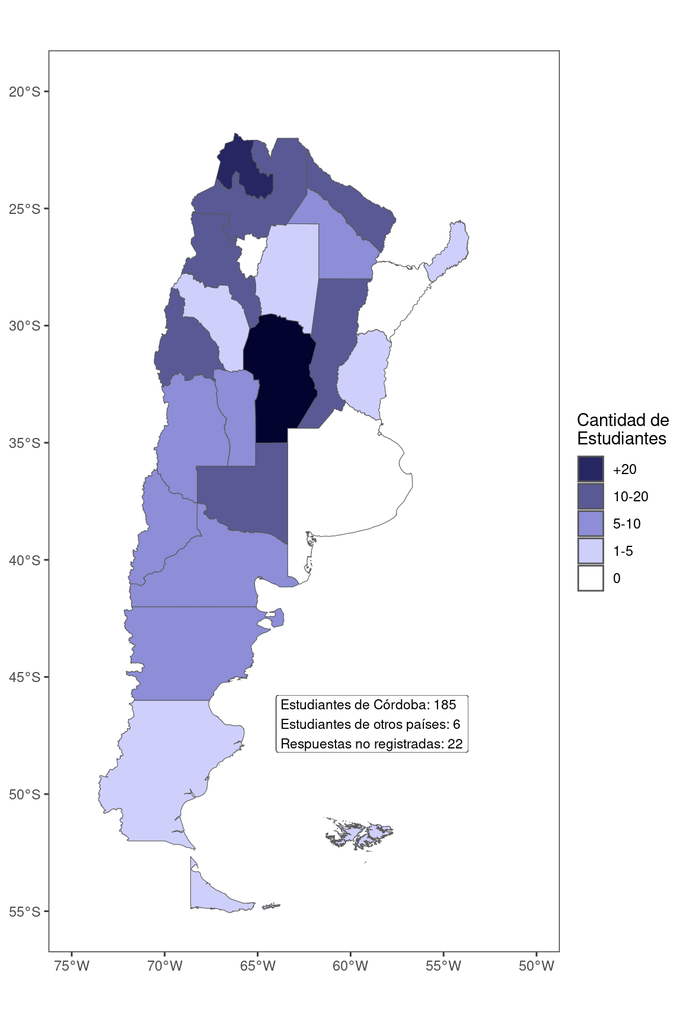

**Figura 3**. Distribución geográfica de los estudiantes de primer año de medicina. Elaborado con datos cartográficos del Instituto Geográfico Nacional (IGN).

Como covariable de interés se incorporó a la base de datos la cantidad de habitantes de las poblaciones de origen de los estudiantes, en base a información del censo 2010 (INDEC, 2010). Un 9.9% de los estudiantes proviene de poblaciones de menos de 10.000 habitantes, mientras que un 31.7% procede de poblaciones de más de 50.000 habitantes, sin considerar Córdoba Capital.

También se agrupó a las provincias por regiones, con el fin de realizar algunos análisis a escala regional.

Una amplia mayoría de los estudiantes no trabaja ni necesita trabajar (73%). Un 11.3% sí trabaja actualmente, y un 19.8% necesita hacerlo para continuar estudiando. Respecto al nivel educativo de los padres, resalta la elevada proporción de estudiantes con al menos un padre con estudios universitarios (31%). Las proporciones en los niveles educativos de madres y padres son similares y hay una alta asociación entre ambas variables, es decir, hay una fuerte tendencia a que ambos padres tengan el mismo nivel educativo.

### Motivaciones y preocupaciones de los estudiantes

En una segunda parte del cuestionario suministrado, se consultó a los estudiantes sobre sus motivos para estudiar en la FCM-UNC, y sobre las amenazas percibidas sobre sus estudios. Al ser preguntas de índole más personal, a cada una de estas preguntas se le añadió una opción de respuesta abierta corta, la cual resultó ampliamente utilizada. Las respuestas obtenidas por dicha vía fueron categorizadas en aspectos generales para facilitar su análisis.

Se consultó en primera instancia por qué eligieron la carrera de medicina. La opción más elegida fue la vocación, expresada en las opciones textualmente como “Desde niño quise ser médico”, opción seleccionada por el 51.8% de los encuestados. Le siguieron “la relevancia del rol del médico en la sociedad” (20.1%) y “el prestigio de la profesión” (7.7%). Un 18.7% de los encuestados optó por la opción abierta, de donde se escinden como principales categorías el interés por ayudar a los demás (4.96%), el interés académico o por el funcionamiento del organismo (4.96%) y la mera curiosidad (4.7%).

Se indagó sobre el motivo de elección de la Universidad Nacional de Córdoba, donde la opción mayoritaria fue el prestigio de la institución (79.3%) seguido de la gratuidad (12.1%). Luego se preguntó sobre cuál es la meta personal del estudiante. Entre las opciones elegidas resaltan “ayudar a la comunidad” (58.7%) y “aportar a la ciencia y la tecnología” (30.9%), siendo opciones minoritarias ayudar a la familia o mejorar la situación económica individual.

Al consultar sobre si los estudiantes sentían amenazada la continuidad de sus estudios, un 26.7% respondió que no, frente a un 73.3% que declaró alguna amenaza. Un 40.5% de los estudiantes identificó a la propia carrera como la principal amenaza, repartiéndose entre la dificultad de los contenidos y la dimensión de la carga horaria. Un 26.4% de los estudiantes acusó a la situación económica actual como su mayor amenaza. Apenas un 1.9% hizo uso de la opción abierta a esta pregunta, siendo el dato llamativo que el factor común en esas respuestas es la situación política del país.

Al comparar las respuestas a esta última variable entre los grupos con diferente situación laboral es posible resaltar la división de los estudiantes en dos grupos: un grupo de estudiantes que necesita trabajar, que pondera factores externos a la universidad como amenazas más graves a sus estudios, primando el malestar económico; y otro grupo de estudiantes que no necesita trabajar, que en buena parte no percibe amenazas a sus estudios, y que de percibirlas, éstas se encuentran más asociadas a cuestiones de la propia carrera de medicina (Figura 4).

La preocupación por la economía también es mayor en estudiantes que terminaron el secundario hace más de tres años.

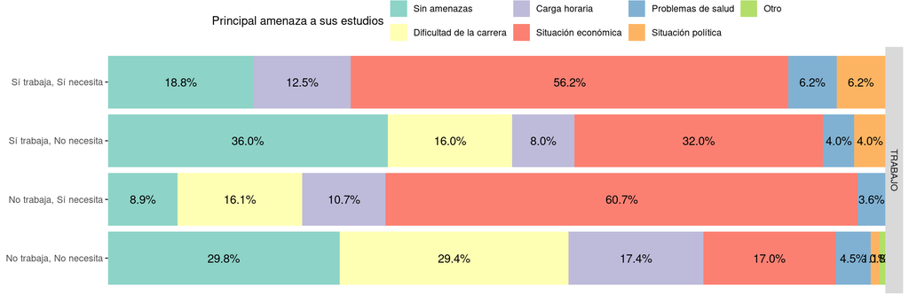

**Figura 4**. Principal amenaza autopercibida para los estudiantes de medicina sobre la continuidad de sus estudios, según situación laboral al momento de la encuesta.

### Perspectiva de desarrollo profesional

En una tercera parte del cuestionario, se preguntó a los estudiantes cómo imaginan su futuro profesional. Se ofrecieron algunas opciones predeterminadas, como así también una opción abierta, siendo posible seleccionar más de una opción. Las opciones por defecto fueron:

Se agregó además una quinta opción para aquellos que aún no habían pensado al respecto, sumada a la ya citada opción de respuesta abierta.

Un 7.7% de los estudiantes no pensó a la fecha cómo sería su futuro profesional. Del resto, una amplia mayoría (78.5%) tildó la opción HAC, la única opción seleccionada por más de la mitad de los estudiantes. Un 25.6% seleccionó INV, un 22% CSB y un 15.7% DOC

Al observar el conjunto de selecciones, se observa que las opciones HAC y CSB se han tomado casi como antónimos, siendo muy poco frecuente la selección de ambas de manera conjunta. La opción CSB fue más elegida por alumnos que tienen por meta personal “ayudar a la comunidad”. Además, hubo una asociación negativa entre la elección de DOC y HAC.

En un contexto donde la emigración de jóvenes está en auge, se consultó a los estudiantes sobre dónde preferirían desarrollar a futuro su profesión, planteando como opciones la localidad de origen, algún otro lugar de Argentina u otro país. Como opciones alternativas se planteó la indiferencia (sic “me daría lo mismo”) y la no consideración (sic “aún no lo pensé”). Un 30.6% de los estudiantes declaró no haber pensado al respecto, mientras que un 8.5% afirmó indiferencia al respecto.

Entre los estudiantes que sí eligieron alguna de las opciones, la mayoría prefirió trabajar en el extranjero (37% entre los que eligieron una opción, 22.6% de la muestra total). Una menor proporción eligió trabajar en su localidad de origen (20.7% del total) y en algún otro lugar de Argentina (17.6%).

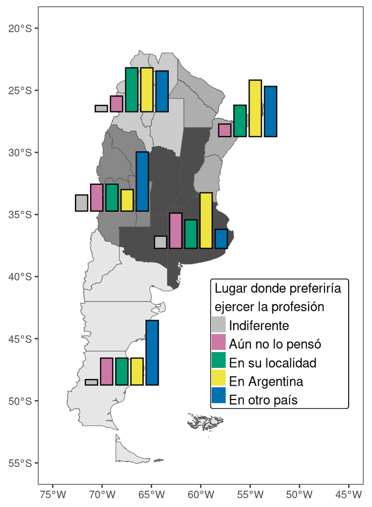

**Figura 5**. Lugar donde los estudiantes preferirían ejercer su profesión, agrupado por regiones (diferenciadas por escala de grises).

En una última instancia, se consultó a los estudiantes sobre qué tan probable consideraban dedicarse a cuatro especialidades en particular: medicina general, pediatría, terapia intensiva y cirugía plástica, calificando dicha probabilidad con un valor numérico en una escala del 1 al 5, donde 1 significaba “Nada probable” y 5 “Muy probable”. Medicina general fue la especialidad con mayor probabilidad de elección (mediana = 3, equivalente a “Medianamente probable”). Al analizar las opciones 4 y 5 (“Algo” y “Muy” probable), la especialidad más elegida resulta pediatría, con un 27.8% de los estudiantes; la menos seleccionada es la especialización en Terapia Intensiva (19%). Respecto a cirugía plástica es de interés resaltar un fuerte rechazo por parte de los estudiantes (43.3% eligió la opción “Nada probable”).

Al cotejar las elecciones con otras variables, se observa una mayor tendencia a elegir Pediatría en estudiantes de sexo femenino o que tienen preferencia por trabajar en un centro de salud barrial/municipal (Figura 6). Esta última variable también se asoció positivamente con mayor probabilidad de elegir medicina general como especialidad.

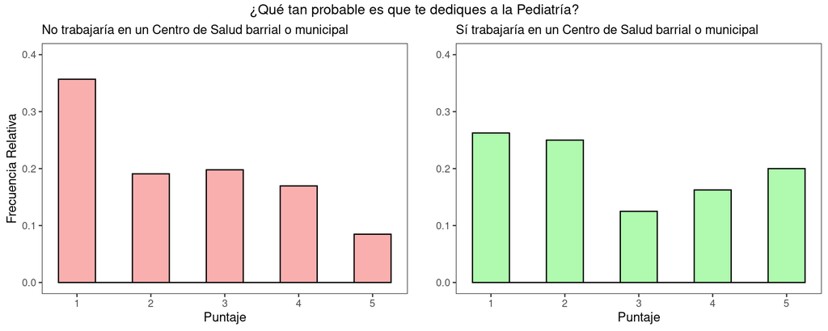

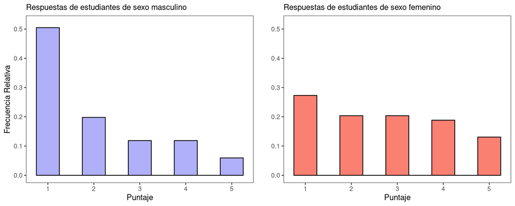

**Figura 6**. Probabilidad auto-declarada de especialización en pediatría de estudiantes de primer año de medicina, clasificados por interés en trabajar en un centro de salud barrial (arriba) y por sexo (abajo).

## Conclusiones

Los estudiantes de primer año de medicina se encuentran motivados por un fuerte sentimiento empático hacia la sociedad, el cual se traduce en un deseo de ayudar a la comunidad, de forma directa o indirecta mediante innovación científica y docencia. Sin embargo, la situación económica, el cambio de localidad de los estudiantes y la necesidad de trabajo que surge tempranamente en su vida universitaria hacen que dejar el país sea una de las opciones más consideradas para el desarrollo de su profesión. Se ha observado un interesante porcentaje de aceptación de ramas de la medicina en las que hay una escasez crítica de profesionales, como pediatría y terapia intensiva. Conocer cómo fluctúan estas tendencias a lo largo de la carrera de medicina podría permitir comprender mejor al estudiantado. Comprender las motivaciones y expectativas de los estudiantes es crucial para mejorar el apoyo académico y las estrategias institucionales.